# Nighttime Lights

Monday · Session 4

Diego A. Guerrero

GDP Growth Nowcasting Workshop | Trinidad and Tobago

## Trinidad and Tobago at night

Artificial light at night is an **indirect measure of activity**:

- energy use, commerce and transport
- **informal** activity that surveys miss
- urban growth and electrification
- disruptions: outages, plant shutdowns, storms

And it arrives **almost in real time**.

~7 days

lag; quarterly GDP for 2026Q1 was the latest available in October 2026

# The data

Part 1

What the satellite measures and how to download it

## The product: NASA Black Marble

| **Product** | VNP46A2: **daily** radiance, corrected for moonlight and atmosphere |
| --- | --- |
| **Resolution** | ~500 m pixels, global coverage |
| **Unit** | nW/cm²/sr |
| **Since** | January **2012** |
| **Access** | NASA LAADS: free account + *token* (expires after 60 days) |
| **Tile for T&T** | one tile, **h11v07** (~25 MB a day) |

## Workflow

1. **Register** at ladsweb.modaps.eosdis.nasa.gov and generate a token
2. **Download the country boundary** (GADM, `gadm41_TTO`)
3. **Download the tiles** for the days you need (only the missing ones)
4. **Aggregate** pixels over the country, or around the sites you care about
5. **Save** the series to `raw/ntl_shape.csv` and `raw/ntl_data.csv`

Everything is driven from `activity/config.py`:

```python
COUNTRY        = "Trinidad and Tobago"
TILES          = ["h11v07"]
NTL_DATE_RANGE = "2026-09-01 2026-09-14"   # two weeks: ~14 files
```

## Two questions, two functions

| Question | Function | Input |
| --- | --- | --- |
| How lit is this **area**? | `processHD5_shape` | a boundary polygon (GADM) |
| How lit is this **site**? | `processHD5` | latitude/longitude points (`raw/Coordinates.xlsx`) |

Both live in `ntl_helpers.py`.

A pixel is about 464 m across, so sites closer together than that share a pixel. `Coordinates.xlsx` lists **76 sites** in six sectors: oil & gas (25), hotels (20), shopping malls (20), seaports (6), airports (3), supermarkets (2).

## The country in one picture

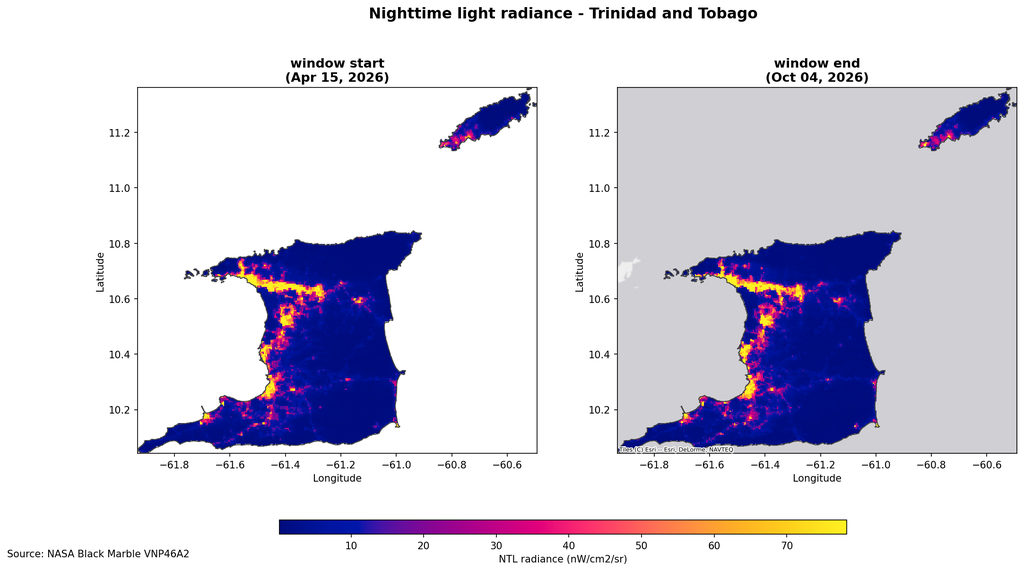

Source: NASA Black Marble VNP46A2, from `1_data_ntl.ipynb` (October 2026 run).

# The signal

Part 2

From pixels to a series

## The daily noise and the quarterly signal

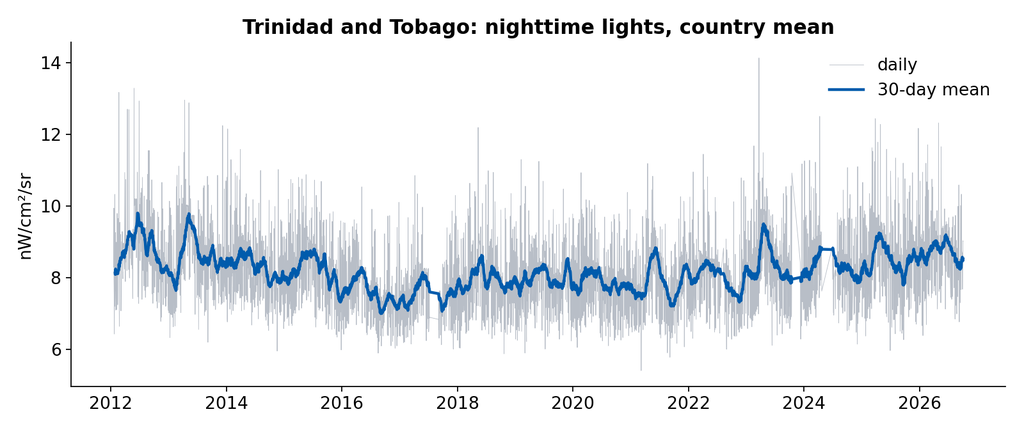

Daily values jump with clouds, moon and fires. A 30-day mean is already readable; the model uses quarterly growth.

## Lights and GDP

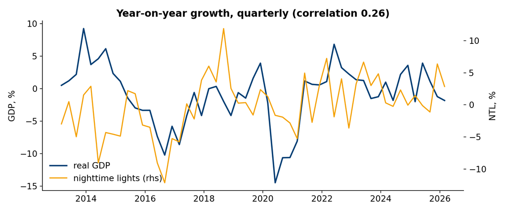

The national series is a **weak** predictor of T&T GDP on its own. Most of the country is dark, and the bright places are not all where value added is produced. That is why we also measure **sites**.

## By sector

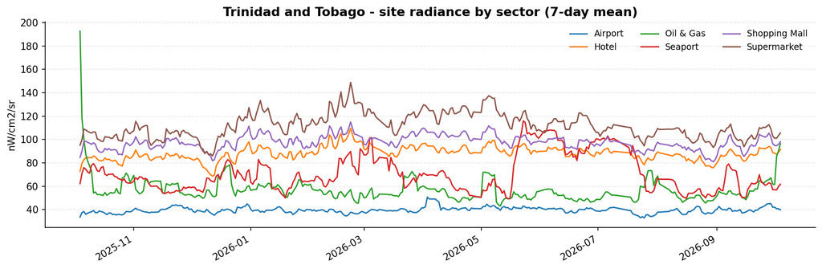

Oil & gas has the brightest single site (Atlantic LNG) but a low average: most of its 25 sites are oilfields and field offices. Supermarkets and malls sit in lit urban areas.

# Oil, gas and nighttime lights

Part 3

Tracking O&G with Nighttime lights

## Why energy infrastructure is a good test

- Flares and industrial plant are **bright, continuous and spatially fixed**
- Start-ups and shutdowns have **known dates**, so the satellite record can be checked against something we already know

Nighttime lights are usually sold as a proxy for GDP. Here we can do something stricter: test whether the lights move when we *know* the economy moved.

## Trinidad and Tobago

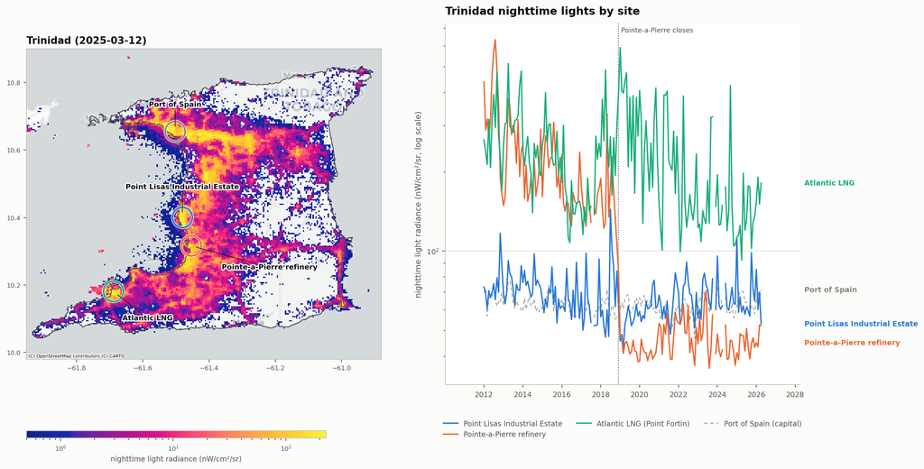

Pointe-à-Pierre refinery closed in November 2018, and lights fall by about three quarters and stay down. Point Lisas (petrochemical estate) still operating, and its lights are flat throughout, tracking Port of Spain.

## A natural experiment

Annual mean of daily radiance, nW/cm²/sr:

| Year | Pointe-à-Pierre | Point Lisas | Atlantic LNG | Port of Spain |
| --- | --- | --- | --- | --- |
| 2016 | 163 | 66 | 163 | 61 |
| 2017 | 152 | 65 | 174 | 60 |
| 2018 | 162 | 72 | 285 | 61 |
| **2019** | **43** | 54 | 361 | 63 |
| 2020 | 41 | 62 | 265 | 63 |

A **treated** site (the refinery), an **untreated** site (Point Lisas) and a **control** (the capital), all in one picture. A forest control pixel stays at ~0.3 throughout, so this is not sensor drift.

## Next door: Guyana offshore

[figure not shown]

Four production vessels, four documented first-oil dates, four step changes in the satellite record. Before 2019 the ocean reads as empty water.

## Reading the charts

- **Light is not output.** A flare measures flaring, not production. Guyana’s flaring fell under regulatory pressure while output grew.
- **What lights are good at**: detecting *new capacity* and *shutdowns* — discrete, dateable events.
- **What they are poor at**: the *level* of production once a facility runs steadily.
- **Trends at a site**: useful for direction and turning points, provided you compare against a benchmark rather than reading the level on its own.

## Other satellite data worth a look

| Source | What | Use for T&T |
| --- | --- | --- |
| Sentinel-5P | NO₂, CH₄ | industrial activity at Point Lisas, flaring |
| VIIRS Nightfire | gas flares | upstream oil & gas activity |
| MODIS / Sentinel-2 | NDVI | agriculture (small share of GDP) |